# Final Project Report Team 5

Miko

2022-12-12

## Investigation in DC crime trend 2016-2021

Professor: Dr. Farhana Faruqe

DATS-6101: Introduction to Data Science

Xuanyu Chen

Yuchuan Feng

Ore Asaba

Osawa Kentaro

Adewale Maye

## 1 Introduction

The goal of our project is to use data provided by the Metropolitan Police Department of Washington DC to gain a good understanding of crime trends in the District. The available data on the Met Police website contains data on adult arrests for years ranging between 2013 and 2021, with a wide range of variables.

Upon inspection of the data sets, we decided to investigate more specifically, the crime trends among Adult White Males in DC from 2016 to 2021, and to check if there have been any changes between time period 2016-2019 (Pre-COVID) and time period 2020- (Post COVID) in the incidence of the major crimes committed in the city. Following our analysis of these trends during our midterm project, we decided to investigate these same crime trends of white males using different variables — particularly the variables of district and age (generation).

## 2 Background and Dataset

### 2.1 Information of the Dataset

The entire dataset upon merging all the different CSV files came up to ~152k observations, while the adult white males came up to ~12k observations. The initial dataset contained 26 variables/columns, but we ended up taking 12 of them out, as they provided little to no use in our analysis. The removed variables are as follows: CCN (Central Complaint Number) which are anonymized, Arrest Number, Arrest Location PSA, Arrest Block GEOX, Arrest Block GEOY, Arrest Latitude, Arrest Longitude, Offense Location PSA, Offense Block GEOX, Offense Block GEOY, Offense Latitude and Offense Longitude. We also created 3 other variables: day, month and weekday.

The variables used are briefly described below: 1 Arrestee Type - all of these were “Adult Arrests”.

2 Arrest Year - the year in which the arrest happened.

3 Arrest Date - the actual date of the arrest, in yyyy-mm-dd format.

4 Month - the month of the arrest, coded with values ranging from 1-12 for each month of the year.

5 Day - The day of the arrest, with values from 1-31 for each date within a month.

6 Weekday - The day of the week for which crime was recorded. Arrest Hour - the hour of arrest, with values from 0 - 24 representing the hours of the day.

7 Age: the arrestee’s self-reported age.

8 Defendant PSA: the last known address of the arrestee - values could be “out of state”.

9 Defendant District: the police district in which the defendant was last seen.

10 Defendant Race: the race of the arrestee - Black, White, Asian, Unknown, Multiple.

11 Defendant Ethnicity: Hispanic, Non-Hispanic and Unknown

12 Defendant Sex: the sex of the arrestee - grouped into Male, Female and Unknown.

13 Arrest Category: the broad name given to the crime types. 29 unique values.

14 Charge Description: brief description of the charge leveled against the arrestee.

15 Arrest Location District: The police district in which the arrest was made.

16 Offense Location District: The police district in which the crime was committed.

### 2.2 Limitations of the Data

There are a few call outs needed to be made about the data set.

1 For the CSV file derived from the Police website for 2019 Arrests Data, there was an issue with the times of the arrest. The data only reported for the first 12 hours (1-12), instead of all 24 (0-23). We believe this would have had an effect on the Hourly analysis we carried out. We removed the 2019 data in that aspect of the Exploratory Data Analysis.

2 The Arrest Date column had to be formatted in the “yyyy-mm-dd” format in order to track the time series.

3 There were few inconsistencies in the Arrest Category column across the different years. The naming methods changed especially in the latter years, so we had to correct this and convert them into uniform values.

4 The observations for Defendant Gender, Race and Ethnicity are based on the police officer’s observations and these might not be completely accurate. It is an estimation for the most part.

5 Regarding address, the MPD are not able to release exact addresses to the general public unless a subpoena or proof of ownership is provided.

6 The date of birth of the arrestees may not be accurate as they are mostly self-reported. An arrestee may also outrightly refuse to provide their date of birth.

## 3 Data Analysis and Results

### 3.1 EDA

#### 3.1.1 SMART Question

Is there a difference in trends of several crime categories among white males between 2016-2021, grouped into Pre and Post COVID periods?

We found that “Simple Assault,” “Traffic Violations,” and “Theft” have a high number of occurrences throughout 2016 to 2021. In addition, “Offenses against Family and Children” increased after the COVID-19 outbreak. Therefore, we divided our data into pre-COVID (2016-2019) and post-COVID (2020-2021) for these crimes and estimated confidence intervals of the number of these crimes per day. As a result, “Simple Assault,” “Traffic Violations,” and “Theft” decreased significantly after the COVID-19 outbreak. On the other hand, The surge in “Offenses against Family and Children” after COVID-19 is attributed to special events (George Floyd protest in DC and Capitol Attack). After excluding cases related to these special events, there is no significant difference in the number of “Offenses against Family and Children” per day before and after the COVID-19.

We did not consider the impact of differences in districts or days of the week on crime in the midterm project. In the final project, we tried to answer the above SMART question in more detail by investigating the impacts of the differences in above categorical variables on the count of “Simple Assault,” “Traffic Violations,” and “Theft” before and after the COVID-19 outbreak.

### 3.2 Model

##### 3.2.2 Two-variable models

###### 3.2.2.1 Building models

First, we created models using “District” and “days of the week” as explanatory variables. There are seven police districts in DC, but the sixth and seventh districts have fewer crimes than the other districts do. Therefore, we focused on from first to fifth districts. In addition, we split “days of the week” into two levels: weekday (Monday - Friday) and weekend (Saturday and Sunday).

The two-way table for “Simple Assault,” “Traffic Violations,” and “Theft” as follows.

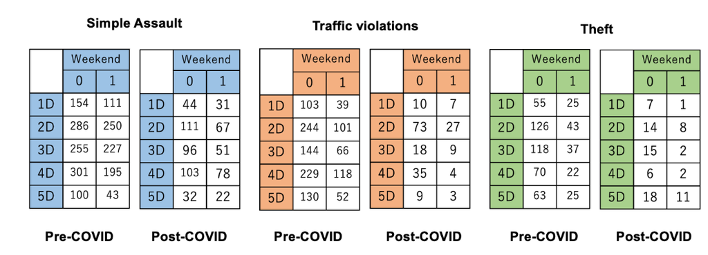

Two-way tables.

###### 3.2.2.2 Evaluating models

**Goodness of fit test** We tested the following hypothesis using the deviance and a chi-squared distribution.
$$H_0: \ \rm{Reduced \ model \ is \ true.}$$
$$H_1: \ \rm{Satureated \ model \ (Model \ 5)
\ is \ true.}$$

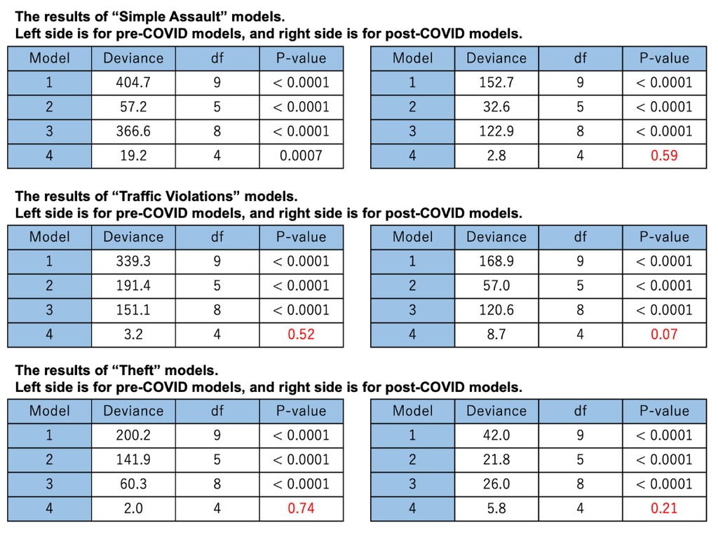

Goodness of fit test.

**AIC and BIC** AIC and BIC calculated for all models are shown in the below table. These results were consistent with the results from the goodness of fit except for the post-COVID model of “Traffic Violations.” For the post-COVID models of “Traffic Violations,” Model 5 was the best from AIC, but Model 4 is the best from BIC. According to Chakrabarti & Ghosh (2011), “The Bayesian Information Criterion (BIC) is more useful in selecting a correct model while the AIC is more appropriate in finding the best model for predicting future observations.” We were interested in inference not prediction. Therefore, we used the result from BIC and concluded the Model 4 was the best.

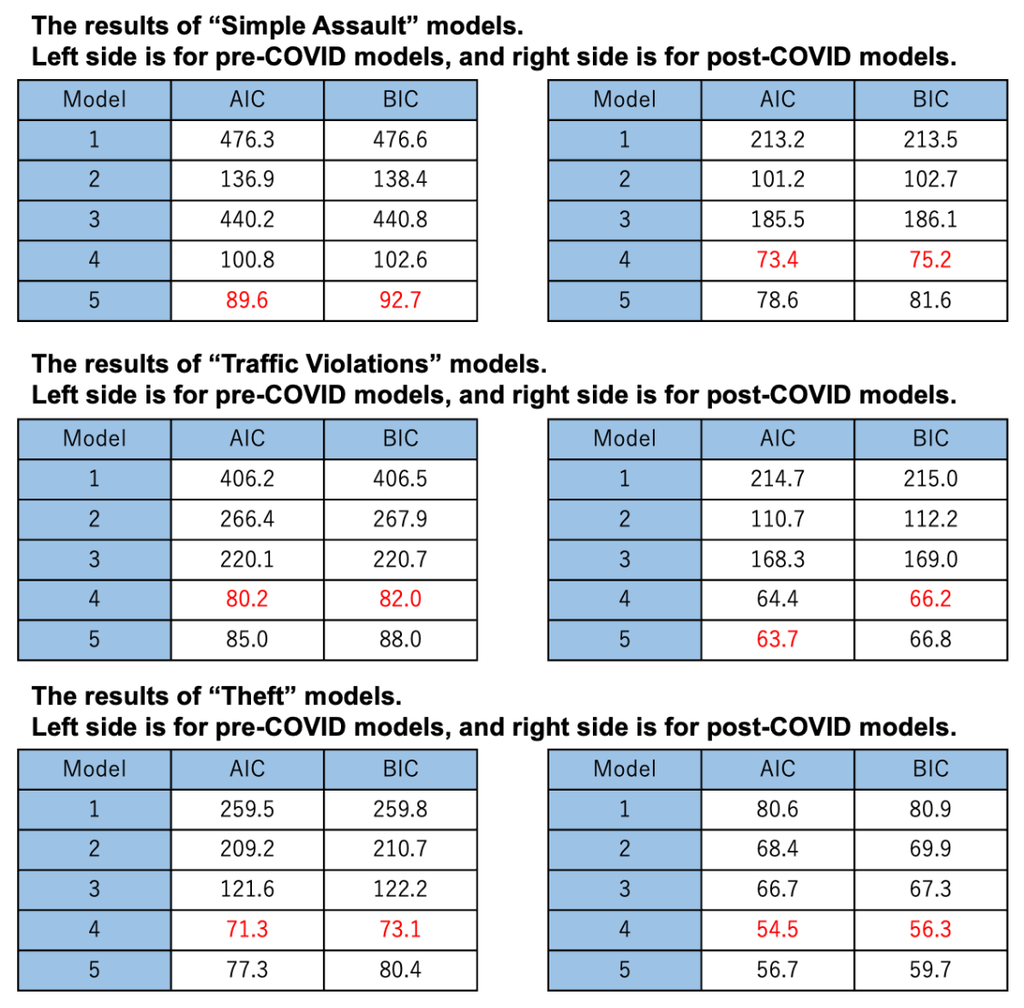

AIC and BIC.

##### 3.2.3 Three-variable models

###### Introduction to Log-linear Models for Three-way Tables

The notation for log-linear models extends to three-way tables as follows. If $\mu_{ijk}$represents the mean for the $i$th, $j$th, and $k$th levels of variables $A$, $B$, $C$ and , respectively, then we write

$$\log(\mu_{ijk})=\lambda + \lambda^A_i +
\lambda^B_j + \lambda^C_k
+\lambda^{AB}_{ij}+\lambda^{AC}_{ik}+\lambda^{BC}_{jk}+\lambda^{ABC}_{ijk},$$

###### Saturated Log-Linear Mode

This model is the default model in a way that serves for testing of goodness-of-fit of the other models. Recall that the saturated model has the maximum number of parameters and fitting a saturated model is the same as estimating ML parameters of distributions appropriate for each cell of the contingency table.

**Main assumption**

The $N=IJK$ counts in the cells are assumed to be independent observations of a Poisson random variable.

**Model structure**:

$\log(\mu_{ijk})=\lambda + \lambda^A_i + \lambda^B_j + \lambda^C_k +\lambda^{AB}_{ij}+\lambda^{AC}_{ik}+\lambda^{BC}_{jk}+\lambda^{ABC}_{ijk}$

Parameter estimation and interpretation

$\lambda$ represents an “overall” effect or a grand mean (on the log scale) of the expected counts, and it ensures that $\sum_i\sum_j\sum_k\mu_{ijk}=n$

$\lambda_i^A$, $\lambda_j^B$, and $\lambda^C_k$ represent the “main” effects of variables $A$, $B$,and $C$, or deviations from the grand mean.

$\lambda^{AB}_{ij}$, $\lambda_{ik}^{AC}$, $\lambda^{BC}_{jk}$ represent the interaction/association between two variables while controlling the third (e.g., conditional odds ratios, test for partial associations) and reflect the departure from independence

$\lambda_{ijk}^{ABC}$ represents the interaction/association between three variables and reflect the departure from independence

If there is a significant interaction term, we typically do not look at the lower-order terms but only interpret the higher-order terms because the values of lower-order terms are coding dependent and can be misleading.

The saturated model has a perfect fit with $G^2=0$ and df = 0 since the number of cells is equal to the number of unique parameters in the model.

###### Complete Independence

This is the most restrictive model in that all variables are assumed to be jointly independent, regardless of any conditioning. Equivalently, this requires that each two and three-way distribution factors into the product of the marginal distributions involved.

**Main assumptions**

The $N=IJK$ counts in the cells are assumed to be independent observations of a Poisson random variable, and there are no partial interactions: $\lambda^{AB}_{ij}=\lambda^{AC}_{ik}=\lambda^{BC}_{jk}=0$ , for all $i, j, k$, and there is no three-way interaction: $\lambda^{ABC}_{ijk}$ for all $i, j, k$.

**Model Structure**:

$$\text{log}(\mu_{ijk})=\lambda+\lambda^{A}_i+\lambda^B_j+\lambda^C_k$$

###### Joint Independence

With three variables, there are three ways to satisfy joint independence. The assumption is that one variable is independent of the other two, but the latter two can have an arbitrary association. For example, if $A$ is jointly independent of $B$ and $C$, which we denote by $(A,BC)$, then $A$ is independent of each of the others, and we can factor the three-way joint distribution into the product of the marginal distribution for $A$ and the two-way joint distribution of $(B,C)$.

**Main assumptions**

(these are stated for the case $(A,BC)$ but hold in a similar way for $(B,AC)$ and $(C,AB)$ as well)

there are no partial interactions involving $A$: $\lambda^{AB}_{ij}=\lambda^{AC}_{ik}=0$, for all $i, j, k$ and there is no three-way interaction: $\lambda^{ABC}_{ijk}=0$ for all $i, j, k$.

**Model Structure**:

$$\text{log}(\mu_{ijk})=\lambda+\lambda^A_i+\lambda^B_j+\lambda^C_k+\lambda^{BC}_{jk}$$

###### Conditional Independence

The assumption is that two variables are independent, given the third. For example $(AC, BC)$

**Main assumptions**

(these are stated for $(AC, BC)$ the case but hold in a similar way for $(AB, BC)$ and $(AB, AC)$ as well): The $N=IJK$ counts in the cells are assumed to be independent observations of a Poisson random variable, and there is no partial interaction between $A$ and $B$: $\lambda^{AB}_{ij}=0$, for all $i, j$, and there is no three-way interaction.

**Model Structure**:

$$\text{log}(\mu_{ijk})=\lambda+\lambda^A_i+\lambda^B_j+\lambda^C_k+\lambda^{AC}_{ik}+\lambda^{BC}_{jk}$$

###### Homogeneous Association

The homogeneous associations model is also known as a model of no-3-way interactions. Denoted by $(AB, AC, BC)$, the only restriction this model imposes over the saturated model is that each pairwise conditional association doesn’t depend on the value the third variable is fixed at. For example, the conditional odds ratio between $A$ and $B$, given $C$ is fixed at its first level, must be the same as the conditional odds ratio between $A$ and $B$, given $C$ is fixed at its second level, and so on.

**Main assumptions**

The $N = IJK$ counts in the cells are assumed to be independent observations of a Poisson random variable, and there is no three-way interaction among the variables

**Model Structure**:

###### Model Selection

According to our usual approach for hierarchical models, where one is a special case of the other, we can use a likelihood ratio test to measure the reduction in fit of the smaller model (null hypothesis), relative to the larger model (alternative hypothesis). The degrees of freedom for these tests are the difference between the numbers of parameters involved between the two models.

### 3.3 Interpretation

#### 3.3.1 Two-variable model

##### 3.3.1.1 Simple Assault

The best models for pre-COVID and post-COVID were Model 5 and Model 4, respectively. The estimated parameters and their 95% confidence intervals from the best model are shown below. The baseline levels in the below figures are “1D” and “Weekend0”.

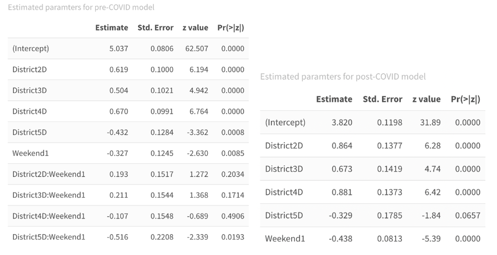

Tables and Figures.

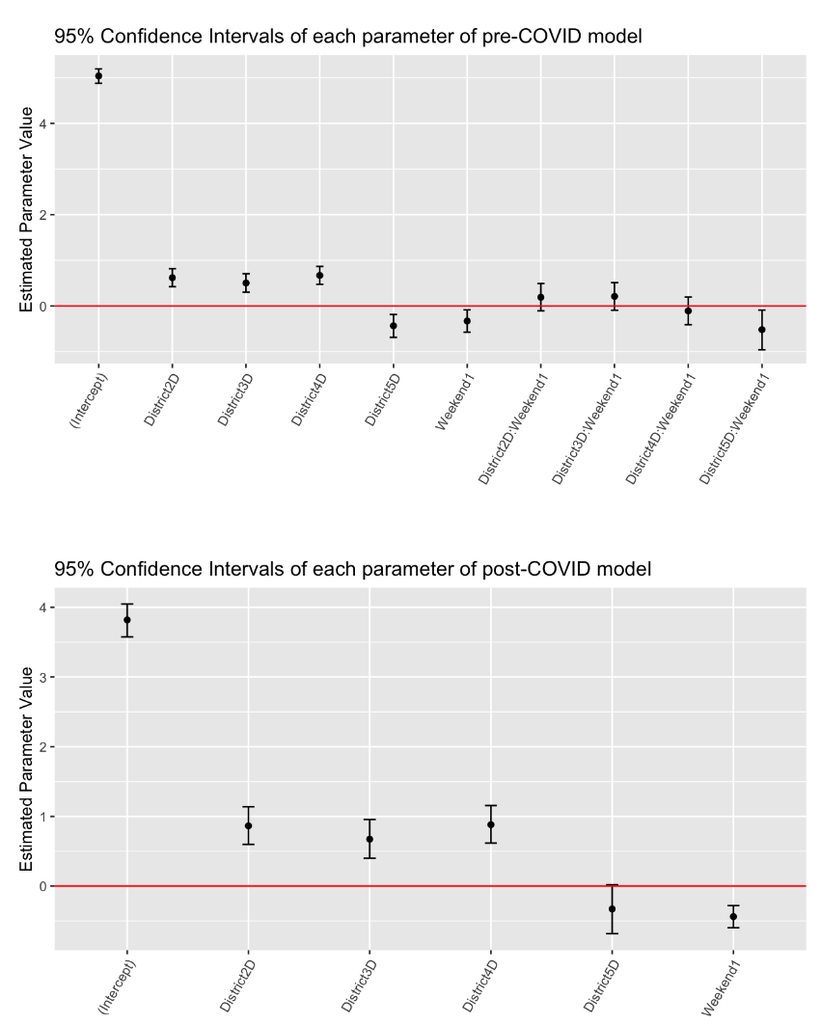

Tables and Figures.

The pre-COVID model has interaction terms, but almost all the terms are insignificant. The interaction between “5D” and “weekend1” is significant, and its value is negative. This means that the combination of “5D” and weekends had the effect of pushing down the count of “Simple Assault.” This could be because more people went to the other districts on weekends before the COVID-19 outbreak. This is plausible since tourist attractions such as the Lincoln Memorial and the Washington Monument exist in the other districts. The interaction between the fifth district and weekends disappeared after the COVID-19.

##### 3.3.1.2 Traffic Violations

The best model was Model 4 for pre-COVID and post-COVID. The below tables and figures show the estimated parameters and their 95% confidence intervals. The baseline levels in the below figures are “1D” and “Weekend0”.

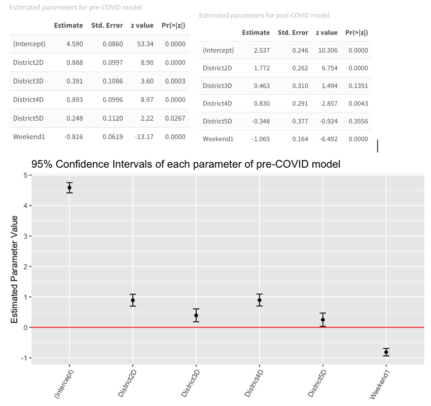

Tables and Figures.

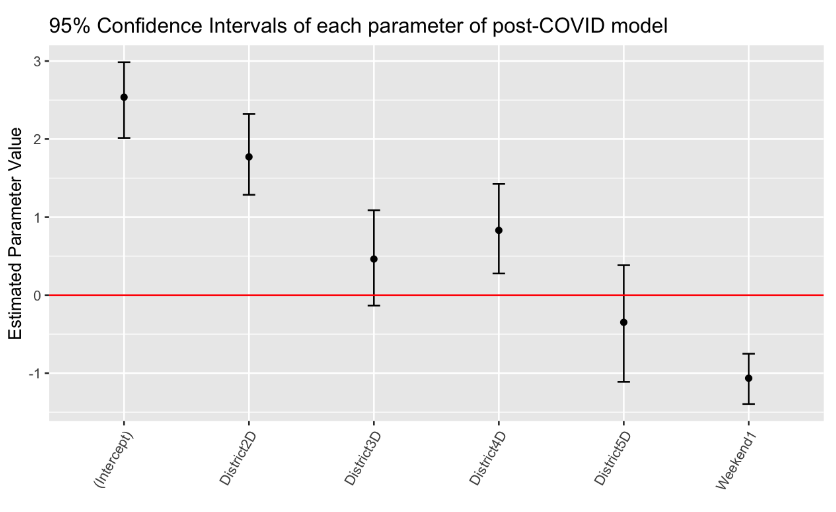

Tables and Figures.

The second district’s parameter is at the same level as the fourth district’s parameter during pre-COVID period but becomes higher than the fourth district’s parameter after the COVID-19. For example, the relationship between the population parameter in 2D on weekend0 ($\mu_{2D,0}$) and the population parameter in 4D on weekend0 ($\mu_{4D,0}$) before the COVID-19 is like this: $\log(\mu_{2D,0}/\mu_{4D,0}) = 0.8877 \ ({\rm{the \ estimated \ 2D \ parameter}}) - 0.8935 \ ({\rm{the \ estimated \ 4D \ parameter}}) = -0.0058$. The relationship between the population parameter in 2D on weekend0 ($\mu_{2D,0}$) and the population parameter in 4D on weekend0 ($\mu_{4D,0}$) after the COVID-19 is like this: $\log(\mu_{2D,0}/\mu_{4D,0}) = 1.7720 \ ({\rm{the \ estimated \ 2D \ parameter}}) - 0.8303 \ ({\rm{the \ estimated \ 4D \ parameter}}) = 0.9417$.

##### 3.3.1.3 Theft

The best model was Model 4 for pre-COVID and post-COVID. The below tables and figures show the estimated parameters and their 95% confidence intervals. The baseline levels in the below figures are “1D” and “Weekend0”.

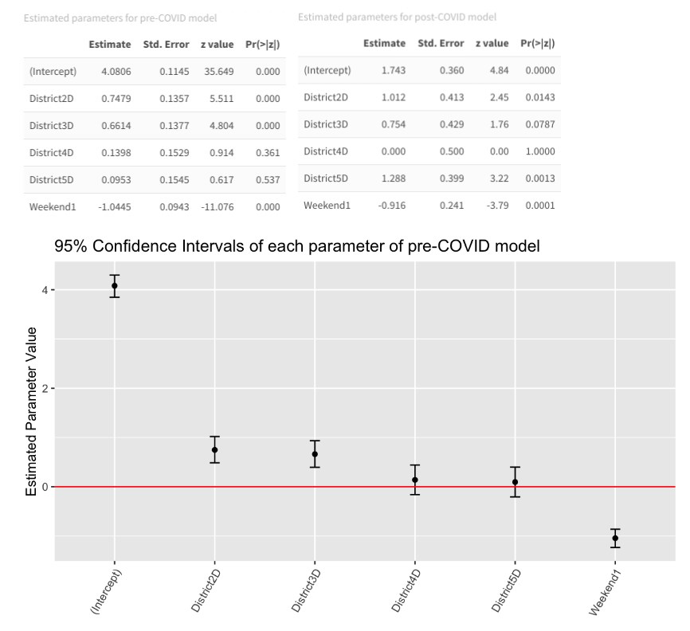

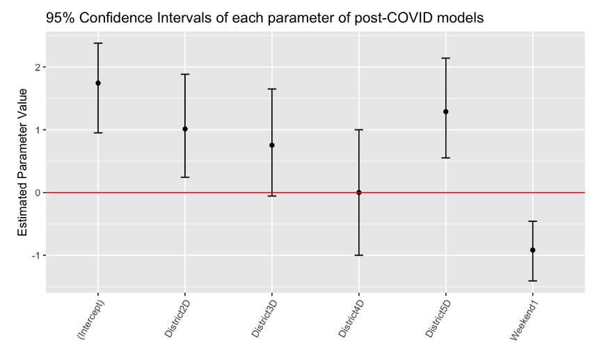

Tables and Figures.

The fifth district’s parameter has small value and is insignificant before the COVID-19 but becomes significant and higher than the other districts’ parameters after the COVID-19. For example, the relationship between the population parameter in 5D on weekend0 ($\mu_{5D,0}$) and the population parameter in 2D on weekend0 ($\mu_{2D,0}$) before the COVID-19 is like this: $\log(\mu_{5D,0}/\mu_{2D,0}) = 0.0953 \ ({\rm{the \ estimated \ 5D \ parameter}}) - 0.7479 \ ({\rm{the \ estimated \ 2D \ parameter}}) = -0.6526$. The relationship between the population parameter in 5D on weekend0 ($\mu_{5D,0}$) and the population parameter in 2D on weekend0 ($\mu_{2D,0}$) after the COVID-19 is like this: $\log(\mu_{5D,0}/\mu_{2D,0}) = 1.2879 \ ({\rm{the \ estimated \ 5D \ parameter}}) - 1.0116 \ ({\rm{the \ estimated \ 2D \ parameter}}) = 0.2763$.

#### 3.3.2 Three-variable model

##### 3-way contingency table

The selected variables are as follows:

**District** (denote as A in the loglinear model): 1D-5D **Day of the week** (B): Monday - Sunday **Generations** (C): Split the criminals into 4 gnerations: 18-24, 25-39, 40-59, 60-80

We selected three crimes as responses: **Simple Assaults**, **Traffic Violations**, **Theft**. Split the data into Pre-Covid(2016-2019) and Post-Covid(2020-2021)

##### Models

1. Mutual independence: ~$A+B+C$
2. Conditional independence ~$(A+B)*C$
3. Joint independence ~$A*B + C$
4. All two-way associations ~$A*B + A*C + B*C$
5. Saturated model ~$A*B*C$

###### AIC and BIC

**Simple Assault**

**Pre-Covid**

| Model | AIC | BIC |
| --- | --- | --- |
| 1 | 716.8396 | **756.877** |
| 2 | 733.8949 | 859.7267 |
| 3 | **708.2202** | 816.893 |
| 4 | 722.8343 | 917.3015 |
| 5 | 786.3359 | 1155.252 |

**Post-Covid**

[output not shown]

(When selecting models, we mainly focus on BIC.) The best model is model 1, independence model ~$A+B+C$

**Traffic Violations**

**Pre-Covid**

| Model | AIC | BIC |
| --- | --- | --- |
| 1 | **640.641** | **680.3489** |
| 2 | 661.7483 | 786.5447 |
| 3 | 647.072 | 754.8507 |
| 4 | 665.0259 | 857.8931 |
| 5 | 723.508 | 1080.88 |

**Post-Covid**

| Model | AIC | BIC |
| --- | --- | --- |
| 1 | **263.8402** | **296.8341** |
| 2 | 301.0655 | 392.9771 |
| 3 | 295.3037 | 382.5019 |
| 4 | 331.8203 | 477.9362 |
| 5 | 358.0042 | 541.8275 |

The best model is model 1, independence model ~$A+B+C$

**Theft**

**Pre-Covid**

| Model | AIC | BIC |
| --- | --- | --- |
| 1 | **459.7798** | **497.7132** |
| 2 | 503.4542 | 622.6735 |
| 3 | 484.726 | 587.6881 |
| 4 | 526.2029 | 710.451 |
| 5 | 591.2977 | 892.0556 |

**Post-Covid**

| Model | AIC | BIC |
| --- | --- | --- |
| 1 | **164.5221** | **192.877** |
| 2 | 197.3682 | 262.1795 |
| 3 | 201.7576 | 272.6449 |
| 4 | 230.6167 | 333.9097 |
| 5 | 238.9594 | 352.3791 |

The best model is model 1, independence model ~$A+B+C$

##### Coeffient plots of the best models

In three-variable modeling, the best models are always independent model ~$A+B+C$ for all crimes in both Pre-Covid and Post-Covid period.

The estimated parameters and their 95% confidence intervals from the best model are shown below.

The base line is: 1D, Friday, Generation A (18-24)

**Simple Assults**

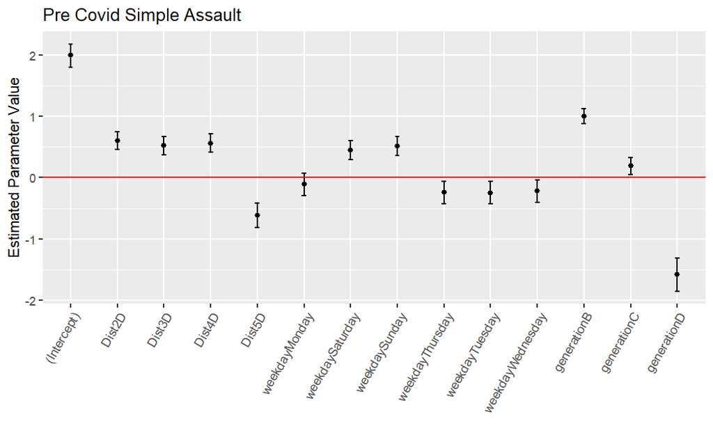

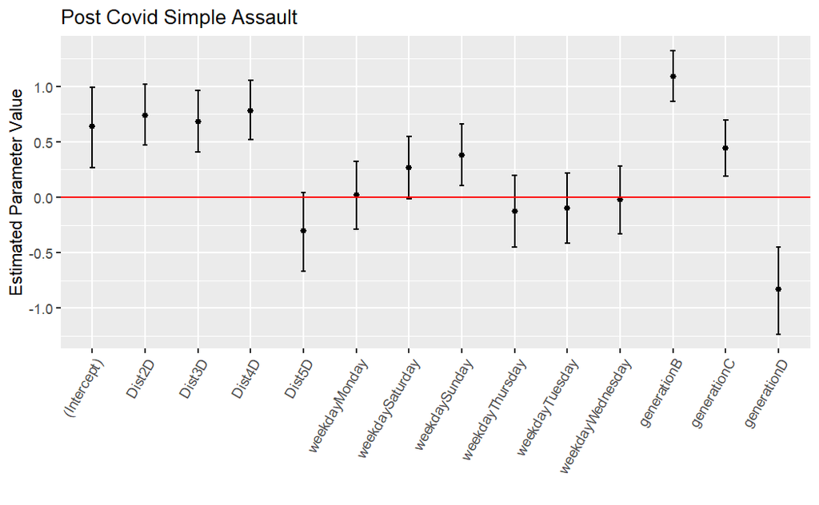

**Traffic Violations**

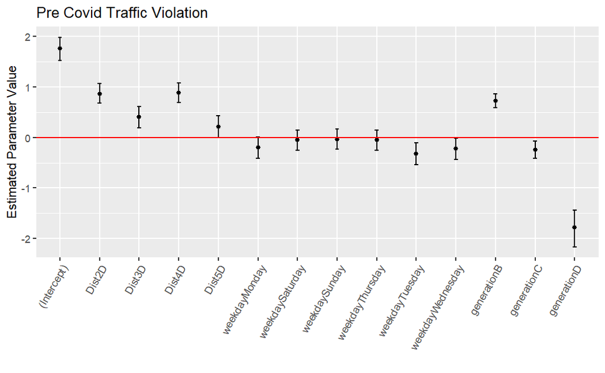

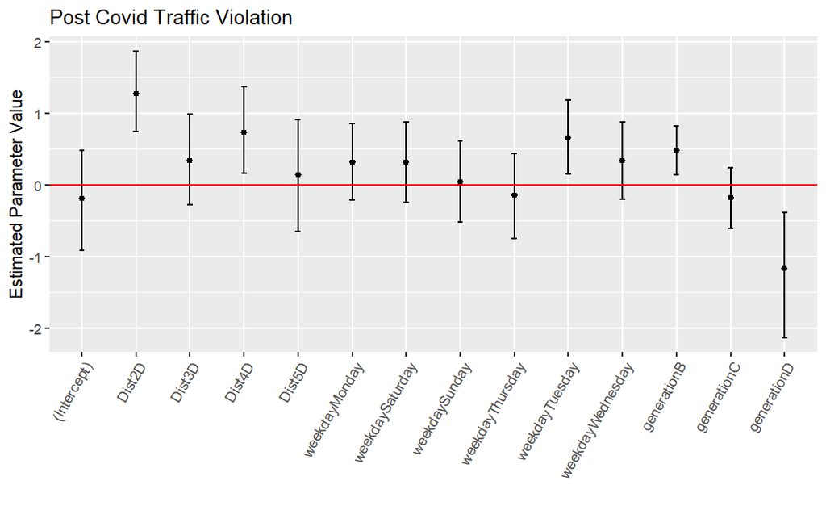

**Theft**

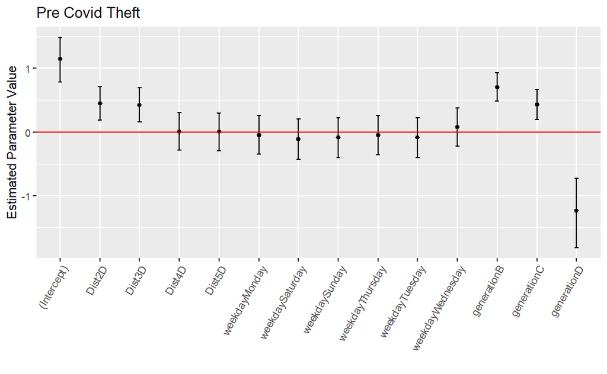

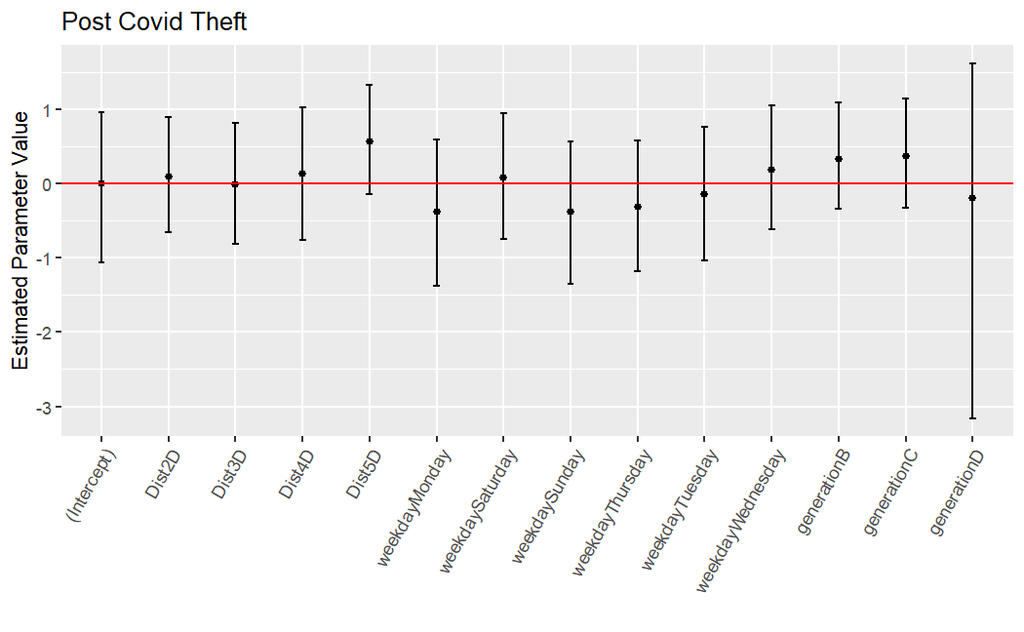

## 4 Conclusion

From the midterm project, we found that COVID-19 seemed to reduce the number of “Simple Assault,” “Traffic Violations,” and “Theft.” In this final project, we also found that COVID-19 changed crime trends. In particular, a significant crime trend change can be seen in the fifth district.

## 5 References

6.3.4 - analysis of deviance and Model Selection: Stat 504. PennState: Statistics Online Courses. (n.d.). Retrieved December 11, 2022, from https://online.stat.psu.edu/stat504/lesson/6/6.3/6.3.4

10: Log-Linear Models: Stat 504. PennState: Statistics Online Courses. (n.d.). Retrieved December 10, 2022, from https://online.stat.psu.edu/stat504/lesson/10

Chakrabarti, A., & Ghosh, J. K. (2011). AIC, BIC and recent advances in model selection. Philosophy of statistics, 583-605.